# Lab 1: The Apollo Missions

## Introduction

Imagine you are an engineer working on the very early days of the Apollo program. In order to send people to the moon, you need a basic understanding of the gravitational potential and forces the mission will experience. You also need to start quantifying the performance of the new rocket that will carry the capsule: the Saturn V.

Your team at NASA has been tasked with conducting a series of investigations, which you are guided through below. You will make some plots, and also write some short paragraphs with your scientific conclusions. The NASA Director Gene Kranz will use your notebook to defend NASA funding to congress. So your answers should be short and to the point, quantitative in nature, and contain highly polished plots, with appropriate titles, units, etc.

**Other important requirements:**

- Your final notebook---BOTH the .ipynb file AND the html export---should be COMMITTED and PUSHED to your fork of the PHYS265-spring26 GitHub repository. Instructions for doing this are available [online](https://github.com/astroumd/PHYS265-spring26/blob/main/github.pdf).
- All plotting should be done in object oriented fashion, as discussed in class. Any use of “`plt.plot()`” will result in zero points being awarded for that question.
- Before submitting your work, reset JLD and then re-run your final code (Kernel → Restart Kernel and Run All Cells…) Make sure your code executes as intended and without error. The first cell should be "1", and the cells should execute in order.

A table of relevant physical constants is below. Good luck!

| Quantity | Value |
| --- | --- |
| Gravitational Constant ($G$) | $6.67 \times 10^{-11}$ m³/kg/s² |
| Gravitational Acceleration ($g$) | 9.81 m/s² |
| Mass of the Earth ($M_E$) | $5.9 \times 10^{24}$ kg |
| Mass of the Moon ($M_M$) | $7.3 \times 10^{22}$ kg |
| Mass of Apollo Command Module | 5500 kg |
| Radius of the Earth ($R_E$) | 6378 km |
| Radius of the Moon ($R_M$) | 1737 km |
| Distance from Earth to Moon ($d_{EM}$) | $3.8 \times 10^{8}$ m |
| Exhaust Velocity of Saturn V Stage 1 (S-1C) ($v_e$) | $2.4 \times 10^{3}$ m/s |
| Burn Rate of S-1C ($\dot{m}$) | $1.3 \times 10^{4}$ kg/s |
| Wet Mass of S-1C ($m_0$) | $2.8 \times 10^{6}$ kg |
| Dry Mass of S-1C ($m_f$) | $7.5 \times 10^5$ kg |

```python
import numpy as np
import matplotlib.pyplot as plt
import pandas as pd
from matplotlib.colors import LogNorm
import scipy
G = 6.67e-11
print(G)
M_earth = 5.9e24
print(M_earth)
R_earth = 6.378e6
print(R_earth)
d_em = 3.8e8
print(d_em)
R_moon = 1.737e6
print(R_moon)
M_moon = 7.3e22
print(M_moon)
m_apollo = 5500
print(m_apollo)
v_exhaust_apollo = 2.4e3
print(v_exhaust_apollo)
Burn_rate_apollo = 1.3e4
print(Burn_rate_apollo)
m_wet_apollo = 2.8e6
print(m_wet_apollo)
m_dry_apollo = 7.5e5
print(m_dry_apollo)
g = 9.81
print(g)
```

```
6.67e-11
5.9e+24
6378000.0
380000000.0
1737000.0
7.3e+22
5500
2400.0
13000.0
2800000.0
750000.0
9.81
```

## Part 1: The Gravitational Potential of the Earth

The gravitational potential at a distance $r$ from a mass $M$ is given by:

$$\Phi(r) = -\frac{GM}{r}$$

where G is the gravitational constant.

1. Code up a function that takes as an input the mass of a body $M$ , the cartesian location of the mass $(x_M , y_M)$, and the location of some distant evaluation point $(x, y)$. Have the function return the potential at the evaluation point. You may consider approximating the Earth as a point particle, but in which case, be careful! For in that approximation, the the potential contains a singularity. In our function, use all modern best practices for coding. E.g. type hints, type checks, pre and post conditions, doc strings, etc.

```python
def phi(x, y, R, M) :  #set location of the mass at the origin, (0,0)

    r = np.sqrt(x**2 + y**2)
    r_safe = np.where(r<R, np.nan, r)

    """This function gives the gravitational potential at a distant location (x,y) on the cartesian plane
    from a given spherical body, with the assumption that body is a point particle.

    Parameters/imputs
    -------------------------------------------------------------------------------------
    x : float
        x coordinate (meters).
    y : float
        y coordinate (meters).
    R : float
        Radius of the body (meters).
    M : float
        Mass of the body (meters).

    Output of the function
    -------------------------------------------------------------------------------------
    Gravitational Potential : float
    Units: (m^2/s^2)

    Potential errors
    -------------------------------------------------------------------------------------
    TypeError :
        If inputs are not float, int, or array elements.
    ValueError :
        If coordinate inputs are for a cartesian point within the radius of the body.
    """

    # Type check
    allowed_types = (int, float, np.ndarray, np.number)
    if not all(isinstance(i, allowed_types) for i in [x, y, R, M]):
        raise TypeError("Inputs must be numeric: int, float, or numpy array.")

    return (-G*M)/r_safe

help(phi)
```

```
Help on function phi in module __main__:

phi(x, y, R, M)
```

2. Make a 1D plot of the absolute value of the gravitational potential $|\Phi|$ as a function of distance $x$ from the surface of the Earth, assuming $y = 0$. Plot out to $1.5\times$ the distance from the Earth to the Moon. Because the potential falls quickly with r, make the y-axis logarithmic to visualize it better.

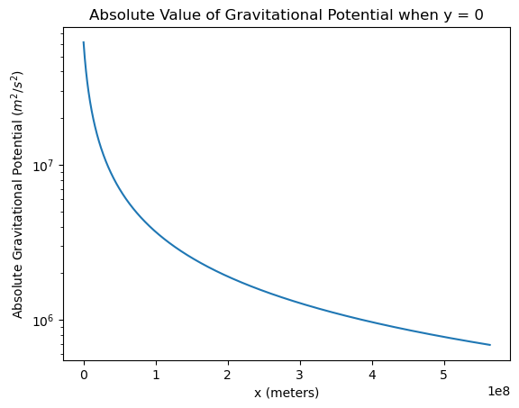

```python
x = np.linspace(R_earth, 1.5*d_em, 1000) #array of x values
Gravitational_Potential_y0 = phi(x, 0, R_earth, M_earth) #creating gravitational potential for earth at y = 0 by inputting into function
Absolute_Gravitational_Potential = np.abs(Gravitational_Potential_y0) #makes the gravitational potential positive (absolute)
fig, ax = plt.subplots() #creating graph and axes
ax.plot((x - R_earth), Absolute_Gravitational_Potential) #plotting gravitational potential along different x values
ax.set_yscale("log") #making the y scale logarithmic
ax.set_xlabel("x (meters)")
ax.set_ylabel("Absolute Gravitational Potential ($m^2 / s^2$)")
ax.set_title("Absolute Value of Gravitational Potential when y = 0") #creating a title
```

3. Then, make a 2D color-mesh plot of the potential $\Phi$ with the Earth at the origin. Plot $|\Phi|$ over a large range of $x$ and $y$, for example, from $-1.5d_{EM}$ to $+1.5d_{EM}$ . Force the plot to have a square aspect ratio. Make sure to add a nice colorbar, and make the colorbar logarithmic.

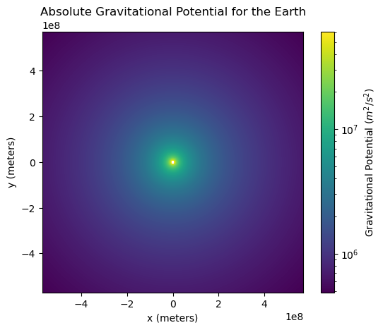

```python
x = np.linspace(-1.5*d_em,1.5*d_em,1000) #building x array
y = np.linspace(-1.5*d_em,1.5*d_em,1000) #building y array
x, y = np.meshgrid(x,y) #combining x and y arrays
Earth_Absolute_Gravitational_Potential = np.abs(phi(x, y, R_earth, M_earth)) #Plugging in values and arrays into the gravitational potential function
fig2, ax2 = plt.subplots() #creating graph and axes
ax2.set_aspect("equal") #forcing a sqaure aspect ratio
mesh = ax2.pcolormesh(x, y, Earth_Absolute_Gravitational_Potential, norm = "log", cmap='viridis') #creating the actual graph, make logarithmic
cbar2 = fig2.colorbar(mesh) #creating colorbar to show values of gravitational potential
cbar2.set_label("Gravitational Potential ($m^2 / s^2$)") #Color Bar label
ax2.set_xlabel("x (meters)") #X axis label
ax2.set_ylabel("y (meters)") #y axis label
ax2.set_title("Absolute Gravitational Potential for the Earth") #title
```

## Part 2: The Gravitational Potential of the Earth-Moon System

Now, imagine the Earth is at the origin $(x_{E},y_{E}) = (0,0)$, and the moon is at a location $(x_{M},y_{M}) = \big( \frac{d_{EM}}{\sqrt{2}}, \frac{d_{EM}}{\sqrt{2}} \big)$.

1. Make an updated 2D color-mesh plot, from $-1.5d_{EM}$ to $+1.5d_{EM}$, of the gravitational potential of the combined Earth-Moon system.

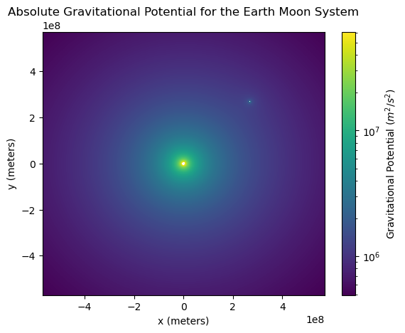

```python
#Creating function

#Location of moon
x_m = d_em/np.sqrt(2) #x coordinate of moon's location
y_m = d_em/np.sqrt(2) #y coordinate of moon's location

def phi2(x, y) :  #set location of the earth at the origin, (0,0)

    #Gravitational Potential of Earth
    r_1 = np.sqrt(x**2 + y**2) #distance from any given cartesian point to the earth
    r_1_safe = np.where(r_1 < R_earth , np.nan, r_1) #ensure the point is ouside the radius of the earth
    GP_1 = (-G * M_earth)/r_1_safe #Gravitational potential for the earth

    #Gravitational Potential of Moon
    r_2 = np.sqrt((x-x_m)**2 + (y - y_m)**2) #Distance from any given cartesian point to the earth
    r_2_safe = np.where(r_2 < R_moon , np.nan, r_2) #Ensure the point is ouside the radius of the earth
    GP_2 = (-G * M_moon)/r_2_safe #Gravitational potential for the earth

    return (GP_1) + (GP_2)  #Add up the gravitational potentials (scalar value)

#Creating Graph

x = np.linspace( -1.5*d_em, 1.5*d_em, 1000) #array of x values
y = np.linspace( -1.5*d_em, 1.5*d_em, 1000) #array of y values
x, y = np.meshgrid(x,y) #combining the arrays
Positive_Gravitational_Potential = np.abs(phi2(x, y)) #Making the values positive
fig3, ax3 = plt.subplots() #creating graph and axes
mesh = ax3.pcolormesh(x, y, Positive_Gravitational_Potential, cmap='viridis', norm = "log") #Creating the color-mesh plot (logarithmic so you can actually see some color not only right at the surface
cbar3 = fig3.colorbar(mesh) #Creating color bar
cbar3.set_label("Gravitational Potential ($m^2 / s^2$)") #Color Bar label
ax3.set_xlabel("x (meters)") #X axis label
ax3.set_ylabel("y (meters)") #y axis label
ax3.set_title("Absolute Gravitational Potential for the Earth Moon System") #title
```

2. Additionally, make a 2D contour plot over the same $x$ and $y$ range. Do not let all the contours bunch up around the Earth and Moon. You will probably again need to tell matplotlib to use a logarithmic color scale.

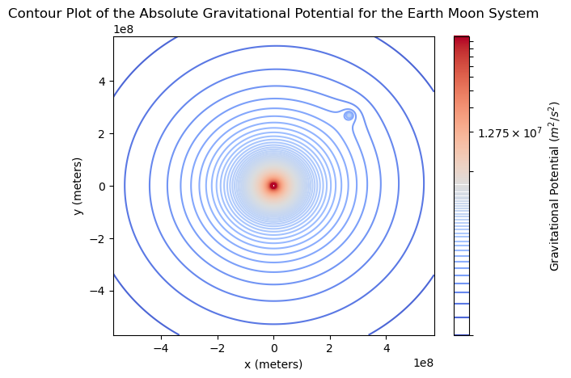

```python
#Using same arrays and variables from part 1
fig4, ax4 =  plt.subplots() #Creating axes and graphs
contour = ax4.contour(x, y, Positive_Gravitational_Potential, cmap = 'coolwarm' , norm = "log", levels = 500) #Creating contour plot, logarithmic because otherwise can see shit, lots of levels to make sure its not just all bunched around earth and moon
cbar4 = fig.colorbar(contour) #Creating color bar
cbar4.set_label("Gravitational Potential ($m^2 / s^2$)") #Color Bar label
ax4.set_xlabel("x (meters)") #X axis label
ax4.set_ylabel("y (meters)") #y axis label
ax4.set_title("Contour Plot of the Absolute Gravitational Potential for the Earth Moon System") #title
```

## Part 3: The Gravitational Force Field of the Earth-Moon System

The gravitational force $\vec{F}$ that a mass $M_1$ exerts on a mass $m_2$ is:

$$\vec{F}_{21} = -G \frac{M_1 m_2}{|\vec{r}_{21}|^2} \hat{r}_{21}$$

where $\vec{r}_{21}$ is the displacement vector from $M_1$ to $m_2$.

1. Code up a function that takes as an input the mass of a body $M_1$, the mass of a secondary body $m_2$, the cartesian location of the first mass $(x_1, y_1)$, and the cartesian location of the second body $(x_2, y_2)$. Have the function return the two gravitational force components, $F_x$ and $F_y$, experienced by the mass $m_2$ from the force exerted by $M_1$. Note that the gravitational force contains a singularity, and so if you made the approximation that the Earth is a finite point, you will need to avoid it. Like for the 1D potential, make sure it follows modern best-coding practices.

```python
def F(x, y, x_M, y_M, R_1, M_1, m_2) :

    r_x = x_M - x
    r_y = y_M - y
    r = np.sqrt((r_x**2) + (r_y**2))
    r_safe = np.where(r < R_1, 1e-10, r)
    F_magnitude = G*(M_1 * m_2)/((r_safe)**2)

    F_x_direction = r_x / r_safe
    F_x = F_magnitude * F_x_direction

    F_y_direction = r_y / r_safe
    F_y = F_magnitude * F_y_direction

    """This function gives the gravitational force components F_x and F_y that the mass M_1 at a cartesian point (x_M, y_M) exerts on a mass m_2 at a location (x,y) with the assumption that the bodies are point particles.

    Parameters/imputs
    -------------------------------------------------------------------------------------
    x : float or int
        x coordinate of m_2 (meters).
    y : float or int
        y coordinate of m_2 (meters).
    x_M : float or int
        x coordinate of M_1 (meters).
    y_M : float or int
        y coordinate of M_1 (meters).
    R_1 : float or int
        Radius of the M_1 body (meters).
    M_1 : float or int
        Mass of the M_1 body (kg).
    m_2 : float or int
        Mass of the m_2 body (kg).

    Output of the function
    -------------------------------------------------------------------------------------
    F_x : x component of the gravitational force
    F_y : y component of the gravitational force
    Units: (Newtons)

    Potential errors
    -------------------------------------------------------------------------------------
    TypeError :
        If inputs are not float, int or array elements.
    ValueError :
        If coordinate inputs (x_M, y_M) are for a cartesian point within the radius R_1 of body M_1.
    """

    # Type check
    allowed_types = (int, float, np.ndarray)
    if not all(isinstance(i, allowed_types) for i in [x, y, x_M, y_M, R_1, M_1, m_2]):
        raise TypeError("Inputs must be numeric: int, float, or numpy array.")

    return F_x, F_y
```

2. Assuming the Earth is still at the origin and the Moon is still at $(x_M, y_M) = \big( \frac{d_{EM}}{\sqrt{2}}, \frac{d_{EM}}{\sqrt{2}} \big)$, make a 2D streamplot of the gravitational force the Earth-Moon system will exert on the Apollo 11 command module. Plot the force over the same x-y range of $-1.5 d_{EM}$ to $+1.5 d_{EM}$. Add a nice color bar, which will again probably need to be logarithmic. Mark the location of the earth with a black circle, and the moon with a black square. Add a legend.

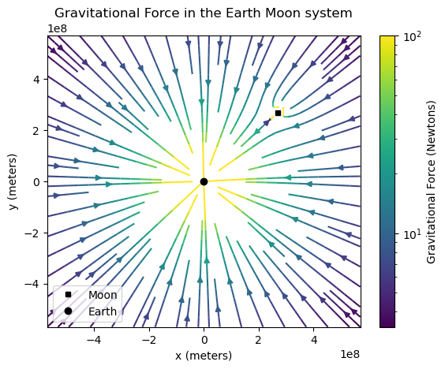

```python
#Building array to graph on

x = np.linspace( -1.5*d_em, 1.5*d_em, 50) #building x arrray
y = np.linspace( -1.5*d_em, 1.5*d_em, 50) #building y array
x, y = np.meshgrid(x,y) #combining x and y arrays

#Creating Force Variables

F_x_earth, F_y_earth = F(x, y, 0, 0, R_earth, M_earth, m_apollo) #Gravitational Forces due to earth
F_x_moon, F_y_moon = F(x, y, (d_em/np.sqrt(2)), (d_em/np.sqrt(2)), R_moon, M_moon, m_apollo) #Gravitational Forces due to moon
F_x = F_x_earth + F_x_moon #Total gravitational force in x direction
F_y = F_y_earth + F_y_moon #Total gravitational force in y direction
Magnitude = np.sqrt(F_x**2 + F_y**2) #Magnitude of the force so I can use a color bar

#Making the actual graph now

fig5, ax5 = plt.subplots() #Building the axes and graph
q = ax5.streamplot(x, y, F_x, F_y, density = 1, cmap= 'viridis', color = Magnitude, norm = LogNorm(vmin=Magnitude.min(), vmax=100))
#Creating object q which graphs the graviational force. vmax is at 100 (trial and error) to avoid messing up the log scale in terms of the colors because force blows up right near the planets
cbar = fig5.colorbar(q.lines, ax=ax5) #Adding a color bar
cbar.set_label("Gravitational Force (Newtons)") #Color Bar label
ax5.set_xlabel("x (meters)") #X axis label
ax5.set_ylabel("y (meters)") #y axis label
ax5.set_title("Gravitational Force in the Earth Moon system") #title
ax5.plot(d_em/np.sqrt(2), d_em/np.sqrt(2), 's', markersize=5, color = "black", label='Moon') #Plotting the Moon
ax5.plot(0, 0, 'o', markersize=6, color = "black", label='Earth') #Plotting the Earth
ax5.legend(loc = 3) #Creates legend, moves it out of the way
```

3. You will note there is a point between the Earth and the Moon where the field lines seem to vanish. This is the point where the Earth's and Moon's gravitational forces cancel eachother. By setting $|\vec{F}_{moon}| = |\vec{F}_{earth}|$, calculate the radial distance of the "balance point." From there, identify the $x$ and $y$ coordinates of the balance point. Typeset your derivation (show multiple steps!) in latex in a markdown cell below. Then, calculate it numerically, and draw the answer onto a new version of your force field plot. Again mark the location of the earth with a black circle, and the moon with a black square; mark the location of the balance point with a red x. Add a legend.

**Your Derivation Goes in the markdown cell below:**

$r_e$ = distance from balance point to earth  
$r_m$ = distance from balance point to moon  
$\frac{GM_em}{r_e^2} = \frac{GM_mm}{r_m^2}$  
$\frac{M_e}{r_e^2} = \frac{M_m}{r_m^2}$  
$r_e = d_{em} - r_m$  
$\frac{GM_em}{(d_{em}-r_m)^2} = \frac{GM_mm}{r_m^2}$  
$\frac{M_e}{M_m}r_m^2= (d_{em} - r_m)^2$  
$\sqrt{\frac{M_e}{M_m}}r_m = d_{em} - r_m$  
$\sqrt{\frac{M_e}{M_m}}r_m + r_m = d_{em}$  
$r_m(\sqrt{\frac{M_e}{M_m}} + 1) = d_{em}$  
$r_m = \frac{d_{em}}{(\sqrt{\frac{M_e}{M_m}} + 1)}$  
$r_e = d_{em} - \frac{d_{em}}{(\sqrt{\frac{M_e}{M_m}} + 1)}$  
x and y coordinates are equal because the moon is equally far away in the x and y direction (45 degree angle)  
$x$ coordinate = $\frac{r_e}{\sqrt{2}}$  
$y$ coordinate = $\frac{r_e}{\sqrt{2}}$  
$x = 241803894.4118111$  
$y = 241803894.4118111$  
Balance point = $(241803894.4118111, 241803894.4118111)$

And your updated plot, including the balance point, goes in the cell below.

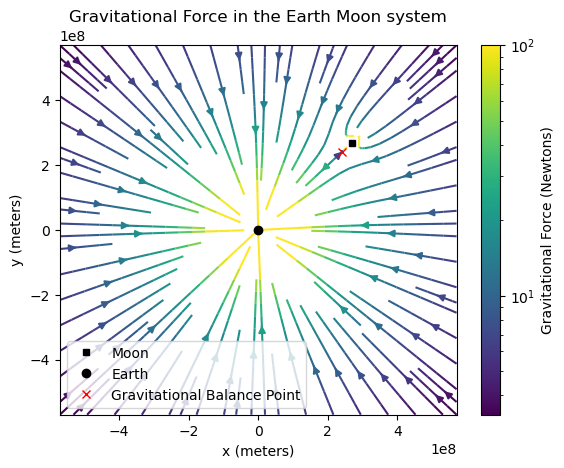

```python
x_balance = 241803894.4118111 #x coordinate of the balance point
y_balance = x_balance #Equal because at 45 degrees

#Building array to graph on

x = np.linspace( -1.5*d_em, 1.5*d_em, 50) #building x arrray
y = np.linspace( -1.5*d_em, 1.5*d_em, 50) #building y array
x, y = np.meshgrid(x,y) #combining x and y arrays

#Creating Force Variables

F_x_earth, F_y_earth = F(x, y, 0, 0, R_earth, M_earth, m_apollo) #Gravitational Forces due to earth
F_x_moon, F_y_moon = F(x, y, (d_em/np.sqrt(2)), (d_em/np.sqrt(2)), R_moon, M_moon, m_apollo) #Gravitational Forces due to moon
F_x = F_x_earth + F_x_moon #Total gravitational force in x direction
F_y = F_y_earth + F_y_moon #Total gravitational force in y direction
Magnitude = np.sqrt(F_x**2 + F_y**2) #Magnitude of the force so I can use a color bar

#Making the actual graph now

fig5, ax5 = plt.subplots() #Building the axes and graph
q = ax5.streamplot(x, y, F_x, F_y, density = 1, cmap= 'viridis', color = Magnitude, norm = LogNorm(vmin=Magnitude.min(), vmax=100))
#Creating object q which graphs the graviational force. vmax is at 100 (trial and error) to avoid messing up the log scale in terms of the colors because force blows up right near the planets
cbar = fig5.colorbar(q.lines, ax=ax5) #Adding a color bar
cbar.set_label("Gravitational Force (Newtons)") #Color Bar label
ax5.set_xlabel("x (meters)") #X axis label
ax5.set_ylabel("y (meters)") #y axis label
ax5.set_title("Gravitational Force in the Earth Moon system") #title
ax5.plot(d_em/np.sqrt(2), d_em/np.sqrt(2), 's', markersize=5, color = "black", label='Moon') #Plotting the Moon
ax5.plot(0, 0, 'o', markersize=6, color = "black", label='Earth') #Plotting the Earth
ax5.plot(x_balance, y_balance, 'x', markersize=6, color = "red", label='Gravitational Balance Point') #Plotting the balance point
ax5.legend(loc = 3) #Creates legend, moves it out of the way
```

4. Quantitatively discuss your conclusions. Is the balance point close to the Moon or Earth? How close? Does this make sense?

**Your Answer Goes in the markdown cell below:**

## Part 4: Altitude of the Saturn V Rocket

Rockets function by conservation of momentum. The ejection of fuel backwards propels the rocket forwards. The change in a rocket's velocity $\Delta v$ as a function of time $t$ (under a set of simplifying assumptions) is given by the Tsiolkovsky rocket equation:

$$\Delta v(t) = v_e \ln \left(\frac{m_0}{m(t)}\right) - gt$$

where $m_0$ is the initial "wet" mass (fuel + rocket parts + payload), $m(t) = m_0 - \dot{m}t$ is the mass at time $t$, $\dot{m}$ is the fuel burn rate (which we will assume to be constant), $v_e$ is the fuel exhaust velocity, and $g$ is the gravitational acceleration.

You can find the altitude $h$ of the rocket at "burnout" (when all the fuel is used up) by integrating the velocity over time:

$$h = \int_{0}^{T} \Delta v(t) \, dt$$

where $T$ is the total burn time of the rocket, Tsiolkovsky rocket equation which by conservation of momentum arguments is:

$$T = \frac{m_0 - m_f}{\dot{m}}$$

where $m_f$ is the final "dry mass" of the rocket, once all the fuel is burned.

1. Calculate the burn time $T$ for the first stage of the new Saturn V rocket that NASA is planning to use to carry the Apollo capsule.

```python
T = (m_wet_apollo - m_dry_apollo) / (Burn_rate_apollo) #plug and chug
print(T) #print value
```

```
157.69230769230768
```

2. Define a function that returns the change in velocity $\Delta v(t)$. It should take all necessary arguments, meaning: the time, wet mass, dry mass, burn rate, exhaust speed, and gravitational constant $g$. Have it return the change in velocity. Note that the rocket eventually runs out of fuel, so you should design your function carefully so that $\Delta v$ eventually becomes zero after all fuel is spent. Again, document and guard your function according to best practices.

```python
def delta_v(t, m_wet, m_dry, burn_rate, v_e, g) : #creating function with necessary arguments
    m_t = m_wet - burn_rate*t #creating m(t) thats in the equation
    rocket_power = v_e * np.log(m_wet/m_t) #effect on rocket from burning fuel
    Fuel_b = (m_wet - m_dry) #Total fuel burnt in first stage
    Fuel_t = t * burn_rate #Fuel burnt over time
    rocket_power_rational = np.where(Fuel_t >= Fuel_b, 0, rocket_power) #Making sure that when fuel runs out the rocket only feels effect of gravitational pull

    """This function gives the change in velocity delta v as a function of time for a rocket using the Tsiolkovsky rocket equation.

    Parameters/imputs
    -------------------------------------------------------------------------------------
    t : float or int
        time (seconds).
    m_wet : float or int
        initial "wet" mass (fuel + rocket parts + payload) (kg).
    x_dry : float or int
        final mass of rocket after all the fuel is spent (kg).
    burn_rate : float or int
        rate at which the rocket fuel burns (kg/s).
    v_e : float or int
        velocity of the exhaust created by burning the rocket fuel (m/s).
    g : float or int
        accelaration due to gravity (m/s^2).

    Output of the function
    -------------------------------------------------------------------------------------
    v(t): the change in velocity over time
    Units: (Newtons)

    Potential errors
    -------------------------------------------------------------------------------------
    TypeError :
        If inputs are not float, int or array elements.

    """
    allowed_types = (int, float, np.ndarray)
    if not all(isinstance(i, allowed_types) for i in [t, m_wet, m_dry, burn_rate, v_e, g]):
        raise TypeError("Inputs must be numeric: int, float, or numpy array.")

    return rocket_power_rational - g*t  #combining effect of burning fuel and effect of gravity
```

3. Compute the altitude of the rocket at the end of the burn. Do this by numerically integrating from $t=0$ (launch) to $t=T$ (burnout). Use the `scipy.integrate.quad()` function.

```python
#help(scipy.integrate.quad)
scipy.integrate.quad(delta_v, 0, T, args=(m_wet_apollo, m_dry_apollo, Burn_rate_apollo, v_exhaust_apollo, g)) #integral
```

```
(74093.98013366401, 5.848811185394151e-08)
```

4. Just last week, NASA got the test results back from the first prototype of Saturn V. They found that it burned for about 160 seconds and lifted the system to an altitude of about 70km. Director Kranz has asked you to compare your calculations for $T$ and $h$ to the testing data. You should offer some explanations about why your calculation is an over or under estimate, e.g. neglecting drag.

**Your Answer Goes in the markdown cell below:**

My calculations for $h$ yielded about 74km which is an overestimate compared to the actual measured height of 70 km. This is likely due to drag, which isn't accounted for in the calculation I performed. This air resistance acts as a counterforce to the rocket boosters, which is why the calculated number is higher than the actual measured number.